# **Market Response Modelling**

Cheryl Isabella

# Project Introduction

This project aims to use market response modelling to develop the right marketing mix for a hypothetical telecommunications provider.

In this scenario, the telecommunications provider currently uses traditional advertising (mainly TV) and Facebook to market its subscriptions.

# Data

This project will analyse how effective the current channels are in acquiring new customers. Therefore, the following data were collected:

- number of newly acquired customers across 118 weeks
- the investment in traditional advertising
- the number of impressions of Facebook posts initiated by the telecommunications provider
- information about media and buzz events, holiday periods, promotions
- marketing buzz about the telecommunications provider on Twitter.

The variables and their descriptions are shown below:

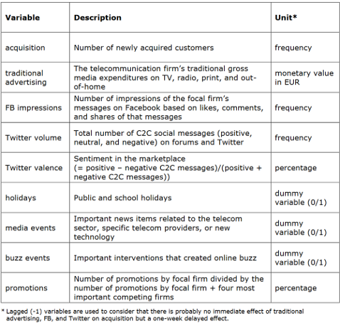

# Categorisation

We commence by categorising all variables in the form of a market response framework.

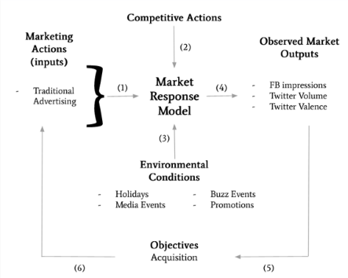

# Linear regression analysis

The data has been cleaned prior to its upload into R. Therefore, we can proceed with a linear regression analysis on the data.

```r
#normalise function
normalize <- function(x) {
  return((x-min(x))/ (max(x)-min(x)))
}

mrm1 = mrm %>% mutate(
  acquisition_n = normalize(acquisition),
  promotions_n = normalize(promotions),
  lag_traditional.advertising_n = normalize(lag_traditional.advertising),
  lag_Twitter_valence_n = normalize(lag_Twitter_valence),
  lag_Twitter_volume_n = normalize(lag_Twitter_volume),
  lag_FB_impressions_n = normalize(lag_FB_impressions)
)

model = lm(acquisition_n ~ buzz.event + media.event + holidays + promotions_n + lag_traditional.advertising_n + lag_Twitter_valence_n + lag_Twitter_volume_n + lag_FB_impressions_n, mrm1)
summary(model)
```

```
##
## Call:
## lm(formula = acquisition_n ~ buzz.event + media.event + holidays +
##     promotions_n + lag_traditional.advertising_n + lag_Twitter_valence_n +
##     lag_Twitter_volume_n + lag_FB_impressions_n, data = mrm1)
##
## Residuals:
##      Min       1Q   Median       3Q      Max
## -0.32888 -0.10356 -0.01784  0.10310  0.51593
##
## Coefficients:
##                                Estimate Std. Error t value Pr(>|t|)
## (Intercept)                    0.068409   0.054156   1.263 0.209219
## buzz.event                     0.005015   0.101408   0.049 0.960645
## media.event                    0.144434   0.041402   3.489 0.000702 ***
## holidays                       0.060637   0.039139   1.549 0.124212
## promotions_n                   0.275896   0.072476   3.807 0.000233 ***
## lag_traditional.advertising_n  0.296964   0.065331   4.546 1.43e-05 ***
## lag_Twitter_valence_n          0.303281   0.096155   3.154 0.002081 **
## lag_Twitter_volume_n          -0.201797   0.070405  -2.866 0.004986 **
## lag_FB_impressions_n           0.084160   0.122632   0.686 0.493995
## ---
## Signif. codes:  0 '***' 0.001 '**' 0.01 '*' 0.05 '.' 0.1 ' ' 1
##
## Residual standard error: 0.1702 on 109 degrees of freedom
## Multiple R-squared:  0.4277, Adjusted R-squared:  0.3857
## F-statistic: 10.18 on 8 and 109 DF,  p-value: 1.565e-10
```

## Regression model performance

The performance of the linear regression model will be evaluated in 3 ways:

### Model Assumptions

Diagnostic plots:

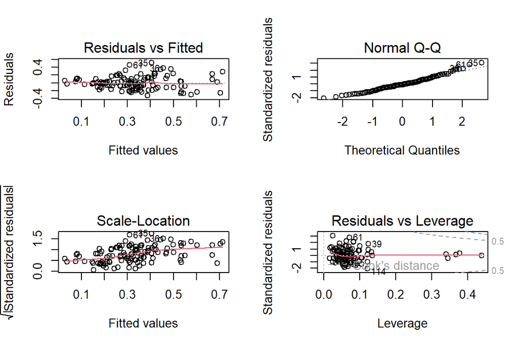

```r
par(mfrow = c(2, 2))
plot(model)
```

### Significance of coefficients (via T-tests)

- Before evaluating the significance of coefficients, I did a two-fold cross validation and split the dataset into a training subgroup with 88 observations and a test set with 30 observations.
- The two-sample T-test for difference in means was used to validate the partitions as the dataset is entirely numerical.

H0: The means between test and training sets are the same

HA: The means between test and training sets are different

```r
#Two fold cross-validation
split <- round(nrow(mrm1)*0.75)
split
```

```
## [1] 88
```

```r
nrow(mrm1) - split
```

```
## [1] 30
```

```r
set.seed(1)
#Function for two-sample t-test
ttest <- function(training, testing) {
  x1_mean <- mean(testing)
  x2_mean <- mean(training)
  s1 <- sd(testing)
  s2 <- sd(training)
  n1 <- length(testing)
  n2 <- length(training)
  dfs <- min(n1-1, n2-1)
  tdata <- (x1_mean - x2_mean) / sqrt((s1^2/n1)+(s2^2/n2))
  tdata
  pvalue <- 2*pt(abs(tdata), df = dfs, lower.tail = FALSE)
  return(pvalue)
}

trainindex <- createDataPartition(mrm1$acquisition_n, p = .75,
                                  list = FALSE,
                                  times = 1)
trainmrm <- mrm1[trainindex,]
testmrm  <- mrm1[-trainindex,]
```

Derivation of coefficients can be found in the associated .rmd file

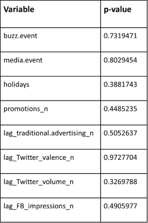

**Results:** Since the p-value of the t-statistic for all explanatory variables are much larger than the 5% significance level, we do not have enough evidence to reject the null hypothesis, meaning that the means of explanatory variables in the Training and Test sets are similar.

# Dynamic effects

- The effort put into marketing sometimes influences sales in future periods. This is known as the carryover effect.
- One type of carryover effect is the delayed-response effect. Some of the variables (e.g., traditional advertising and Twitter volume) are delayed by one week. This has been done to account for the delayed effect this action might have on acquisition.
- This model takes into account some dynamic effects that are relevant to this case.
- However, the inclusion of information from past observations of a series does not necessarily include other omitted variables that may explain some of the historical variations, and that may lead to more accurate forecasts.

# Influence of traditional advertising on acquisition

- The coefficient for traditional advertising is 0.297 (3sf). This means that traditional advertising and acquiring new customers are positively correlated.
- That is, when traditional gross media expenditures increase, the number of newly acquired customers is likely to increase.
- Note: 0.297 is a proportional effect.

# Influence of FB impressions on acquisition

# Conclusion

Most effective communication channel (traditional advertising, Facebook, Twitter) in stimulating customer acquisition:

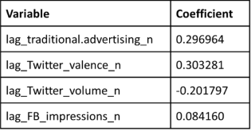

**Recommendations for telecommunication provider**

- As seen from the quantitative evaluation of coefficients, the use of more modern advertising, notably Twitter, is recommended for the telecommunication provider . This “digital first” approach would be a more holistic marketing communication campaign as it meet the changing consumer landscape of tech savvy consumers.
- Further, the telecommunication provider could consider reaching prospective consumers through personal communication channels (eg face-to-face pitches) and buzz marketing to capitalise on word-of-mouth influence for higher acquisition and profits.
- Lastly, the firm should also evaluate the return on advertising investment through the sales and profits effects. This can be done by comparing past sales and profits with past advertising expenditures, or through experiments(eg varying the amount it spends on advertising in different market areas and measuring the differences in the resulting sales/acquisition and profit levels.